# Stat 480 - Homework #6

2/22/2018

## Ames housing

1. Download the RMarkdown file with these homework instructions to use as a template for your work. Make sure to replace “Your Name” in the YAML with your name.
2. The Ames based, non-profit company OAITI provides aoe open-source data sets. One of these data sets consists of information on all house sales in Ames between 2008 and 2010. The following piece of code allows you to read the dataset into your R session. How many house sales were there between 2008 and 2010? Which type of variables are we dealing with?
   - 1,615 houses were sold in Ames between 2008 and 2010.
   - All variables except for `Neighborhood` and `HouseStyle` are integer. The other two variables are factors.

```r
str(housing)
```

```
## 'data.frame':    1615 obs. of  10 variables:
##  $ SalePrice   : int  215000 124500 105000 172000 176500 157000 244000 237500 206900 345000 ...
##  $ Bedrooms    : int  3 2 2 3 3 4 3 4 4 4 ...
##  $ Baths       : int  1 1 1 1 1 2 2 2 2 2 ...
##  $ LotArea     : int  31770 13008 11622 14267 11029 10200 11160 12925 11075 13860 ...
##  $ LivingArea  : int  1656 882 896 1329 1414 1434 2110 2117 2112 2704 ...
##  $ GarageArea  : int  528 502 730 312 601 528 522 550 576 538 ...
##  $ Neighborhood: Factor w/ 33 levels "Blmngtn","Blueste",..: 19 19 19 19 19 19 19 19 19 19 ...
##  $ HouseStyle  : Factor w/ 8 levels "1-Story","1.5 Fin",..: 1 1 1 1 1 1 1 1 4 8 ...
##  $ YearBuilt   : int  1960 1956 1961 1958 1958 1974 1968 1970 1969 1972 ...
##  $ YearSold    : int  2010 2009 2010 2010 2008 2009 2010 2008 2008 2009 ...
```

3. Do sales prices change over time? (Don’t test significances) Provide a graphic that supports your statement.
   - According to the graphic below, sales prices may change over time. The boxplots indicate that 2009 had the highest median sale price, and the red dots indicating mean sales price support this notion. However, the maximum sales price appears to decrease with time. The opposite could be said about the minimum sales price: it increased with time. However, the differences described above are subtle.

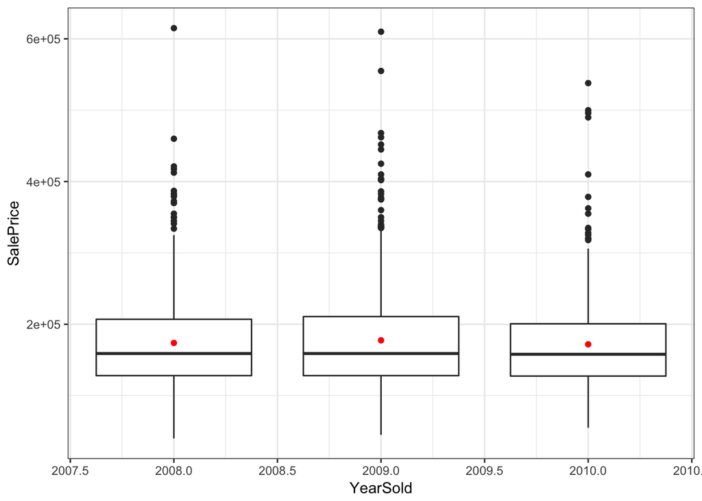

```r
library(ggplot2)
ggplot(housing, aes(x = YearSold, y = SalePrice)) +
  geom_boxplot(aes(group = YearSold)) +
  stat_summary(fun.y = "mean", geom = "point", colour = "red") +
  theme_bw()
```

4. What is the relationship between sales prices and the size of the house (living area)? Make a chart and describe the relationship.
   - The relationship between sales prices and the size of the house is a strong, positive, linear relationship. More variation in sales price occurs as living area gets large.

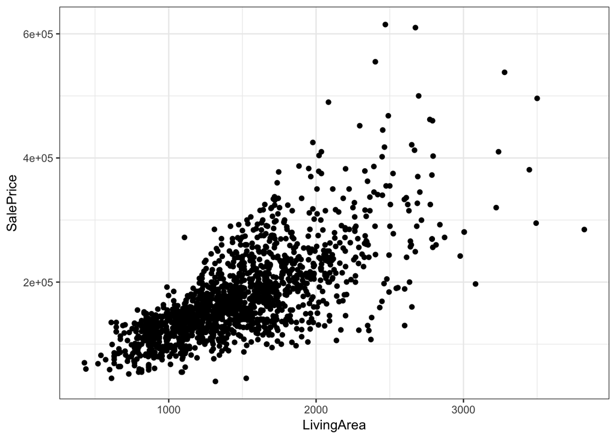

```r
ggplot(housing, aes(x = LivingArea, y = SalePrice)) +
  geom_point() +
  theme_bw()
```

5. Use `dplyr` functions to:
- introduce a variable consisting of price per square foot,
- find the average price per square foot in each of the Ames neighborhoods, - exclude averages that are based on fewer than 10 records,
- reorder the remaining neighborhoods according to the mean sales prices.

```r
library(dplyr)
housing %>%
  mutate(price_per_sqft = SalePrice / LivingArea) %>%
  group_by(Neighborhood) %>%
  summarise(mean_price_per_sqft = mean(price_per_sqft),
            ct = n(),
            mean_sales_price = mean(SalePrice)) %>%
  filter(ct >= 10) %>%
  arrange(mean_sales_price) %>%
  select(-ct, -mean_sales_price)
```

```
## # A tibble: 27 x 2
##    Neighborhood mean_price_per_sqft
##    <fct>                      <dbl>
##  1 MeadowV                     97.5
##  2 IDOT&RR                     90.5
##  3 Br'Dale                     97.5
##  4 Landmrk                     96.5
##  5 IOCondo                    114
##  6 Blueste                    109
##  7 OldTown                     92.2
##  8 BrkSide                    103
##  9 Edwards                    103
## 10 Sawyer                     126
## # ... with 17 more rows
```

6. Draw a chart of the average sale prices by neighborhood and comment on it. Only consider neighborhoods with at least 10 sales.  
   *Extra challenge* (0.5 point extra credit): write the code for this question and the previous one in a single statement.
   - Mean sales prices range from $94,000 to $310,000, with NridgHt and NoRidge having mean sales prices over $300,000. It appears that approximately 50% of neighborhoods have mean sales prices below $150,000.

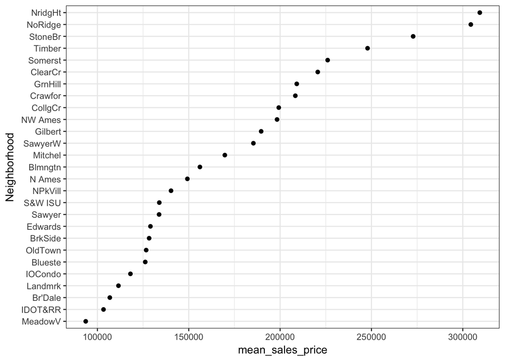

```r
housing %>%
  mutate(price_per_sqft = SalePrice / LivingArea) %>%
  group_by(Neighborhood) %>%
  summarise(mean_price_per_sqft = mean(price_per_sqft),
            ct = n(),
            mean_sales_price = mean(SalePrice)) %>%
  filter(ct >= 10) %>%
  arrange(mean_sales_price) %>%
  mutate(Neighborhood = factor(Neighborhood, levels = Neighborhood)) %>%
  ggplot(aes(x = Neighborhood, y = mean_sales_price)) +
  geom_point() +
  theme_bw() +
  coord_flip()
```

7. Use `dplyr` functions to:
- introduce a logical variable called ‘garage’ that is FALSE if the garage area is zero, and TRUE otherwise,
- exclude all sales of houses that do not have a garage,
- only consider 1 and 2 story houses (`HouseStyle`),
- create a new variable `YBCut` from `YearBuilt` that introduces age categories that groups the year a house was built into intervals: 1800-1850, 1850-1900, 1950-2000, 2000+ (see `?cut`).

```r
house1 <- housing %>%
  mutate(garage = ifelse(GarageArea == 0, FALSE, TRUE)) %>%
  filter(garage == TRUE) %>%
  filter(HouseStyle == "1-Story" | HouseStyle == "2-Story") %>%
  mutate(YBCut = cut(YearBuilt, c(1800, 1850, 1900, 1950, 2000, 2010),
                     labels = c("1800-1850", "1850-1900", "1900-1950", "1950-2000", "2000+")))
```

6. Draw a chart of the previous data set. Draw side-by-side boxplots of the garage area by `YBCut`. Facet by the style of house. Describe and summarise the chart.  
   *Extra challenge* (0.5 point extra credit): write the code for this question and the previous one in a single statement.
   - The chart below has two panes: the pane on the left is for 1-story houses and the pane on the right is for 2-story houses. In each pane there are side-by-side boxplots showing garage area by year. Year is grouped into 4 intervals (on the chart): 1850-1900, 1900-1950, 1950-2000, and 2000+. For one story houses, median garage size appears to be lower for 1900-1950 than 1850-1900, but increases from 1900 on. The same story can be told for 2-story houses. Median garage size is smaller for 1-story houses built in 1850-2000 than it is for 2-story houses. However, median garage size is larger for 1-story houses built after 2000. There appears to be more extreme outliers in the pane for 2-story houses than that for 1-story houses.

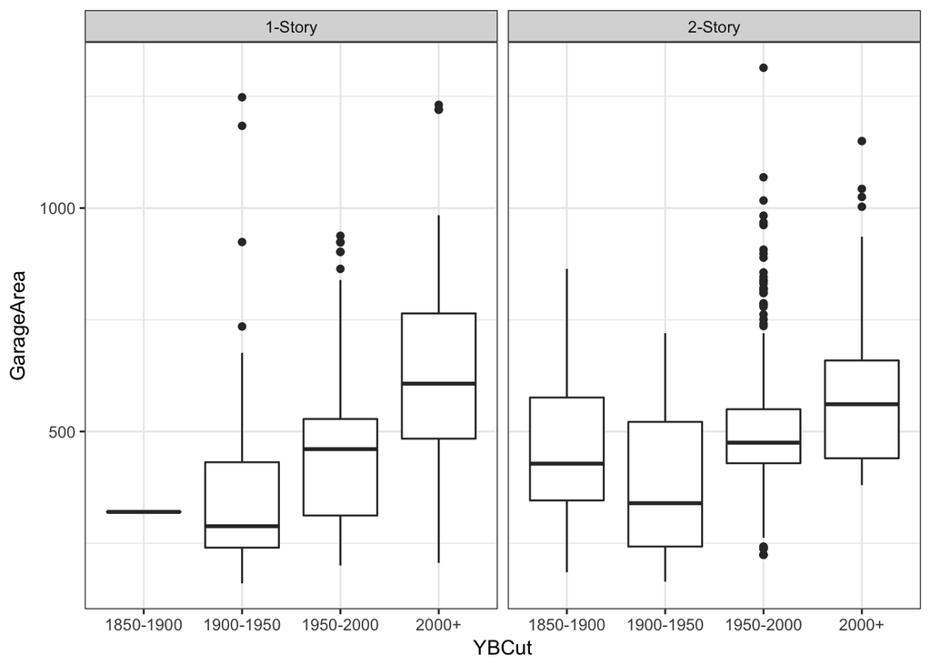

```r
housing %>%
  mutate(garage = ifelse(GarageArea == 0, FALSE, TRUE)) %>%
  filter(garage == TRUE) %>%
  filter(HouseStyle == "1-Story" | HouseStyle == "2-Story") %>%
  mutate(YBCut = cut(YearBuilt, c(1800, 1850, 1900, 1950, 2000, 2010),
                     labels = c("1800-1850", "1850-1900", "1900-1950", "1950-2000", "2000+"))) %>%
  ggplot(aes(x = YBCut, y = GarageArea)) +
  geom_boxplot() +
  facet_wrap(~ HouseStyle) +
  theme_bw()
```

Due date: the homework is due before class on Thursday.

For the submission: submit your solution in an R Markdown file and (just for insurance) submit the corresponding html file with it.